# Homework 2: Image Compression

## PCA Compression Function

```r
pca_compress <- function(x, k) {
  V <- t(x) %*% x
  eig <- eigen(V)
  U <- eig$vectors
  Z <- x %*% U
  Uk <- U[, 1:k, drop = FALSE]
  Zk <- Z[, 1:k, drop = FALSE]
  X_k <- Zk %*% t(Uk)
  err <- norm(x - X_k, type = "F")
  return(list(approx = X_k, error = err))
}

load_image <- function(path) {
  x <- read_csv(path, show_col_types = FALSE)
  data.matrix(x)
}

show_image <- function(mat, main = "") {
  image(t(apply(mat, 2, rev)), col = gray.colors(256), axes = FALSE, main = main)
}

error_curve <- function(x) {
  V <- t(x) %*% x
  eig <- eigen(V)
  U <- eig$vectors
  Z <- x %*% U
  p <- ncol(x)
  errors <- numeric(p)
  for (k in 1:p) {
    X_k <- Z[, 1:k, drop = FALSE] %*% t(U[, 1:k, drop = FALSE])
    errors[k] <- norm(x - X_k, type = "F")
  }
  list(errors = errors, U = U, Z = Z)
}
```

## Image 1

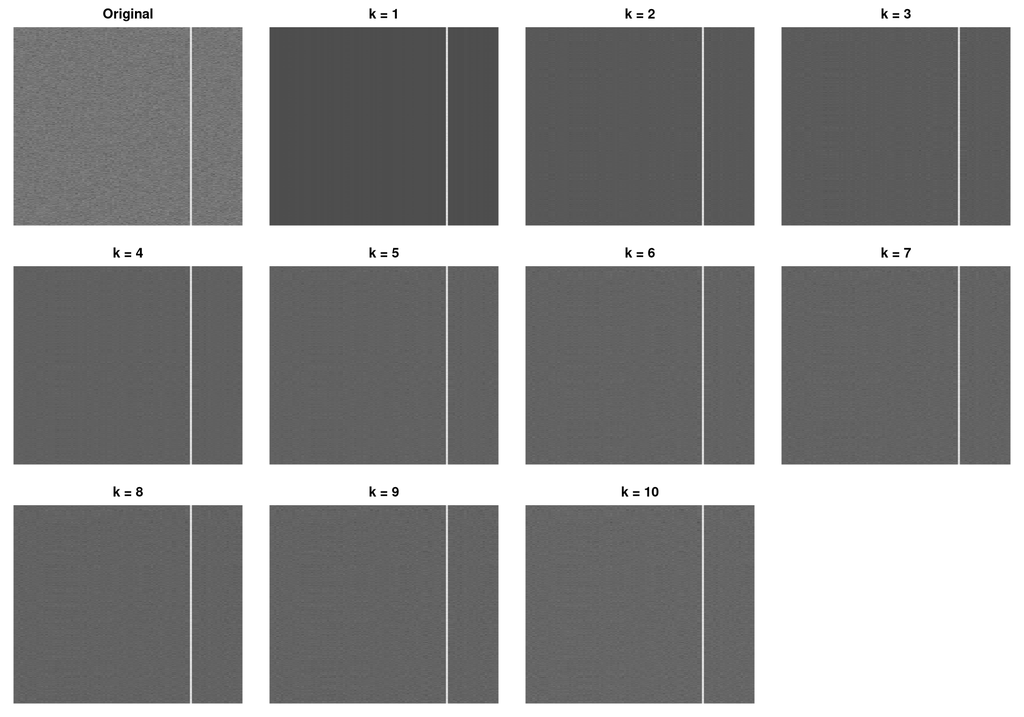

```r
img1 <- load_image("image1.csv")
par(mfrow = c(3, 4), mar = c(1,1,2,1))
show_image(img1, main = "Original")
for (k in 1:10) {
  res <- pca_compress(img1, k)
  show_image(res$approx, main = paste0("k = ", k))
}
```

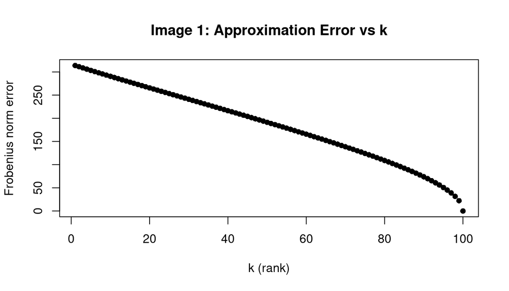

```r
par(mfrow = c(1, 1))
ec1 <- error_curve(img1)
plot(seq_along(ec1$errors), ec1$errors, type = "b", pch = 16,
     xlab = "k (rank)", ylab = "Frobenius norm error",
     main = "Image 1: Approximation Error vs k")
```

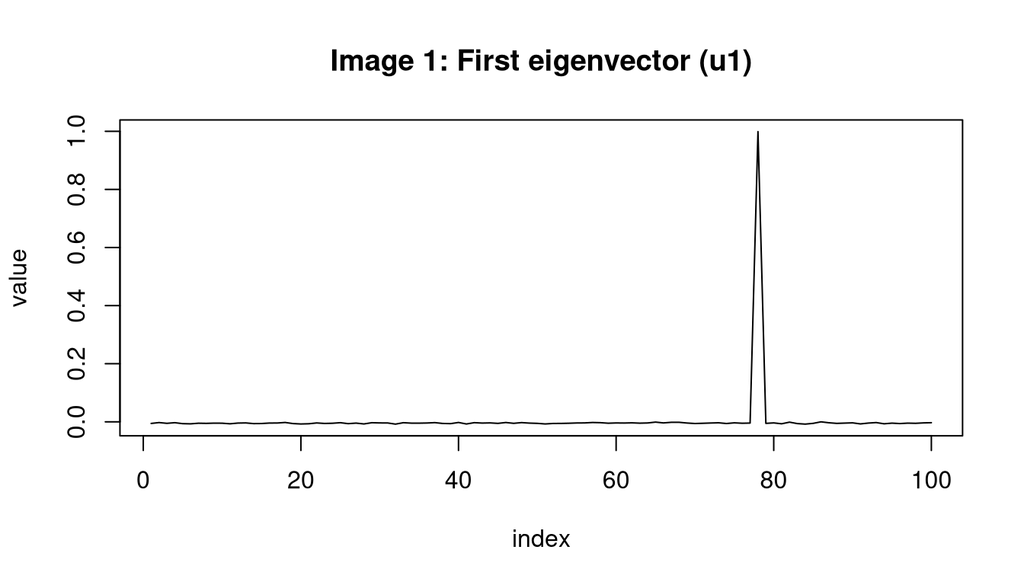

```r
plot(ec1$U[, 1], type = "l", xlab = "index", ylab = "value",
     main = "Image 1: First eigenvector (u1)")
```

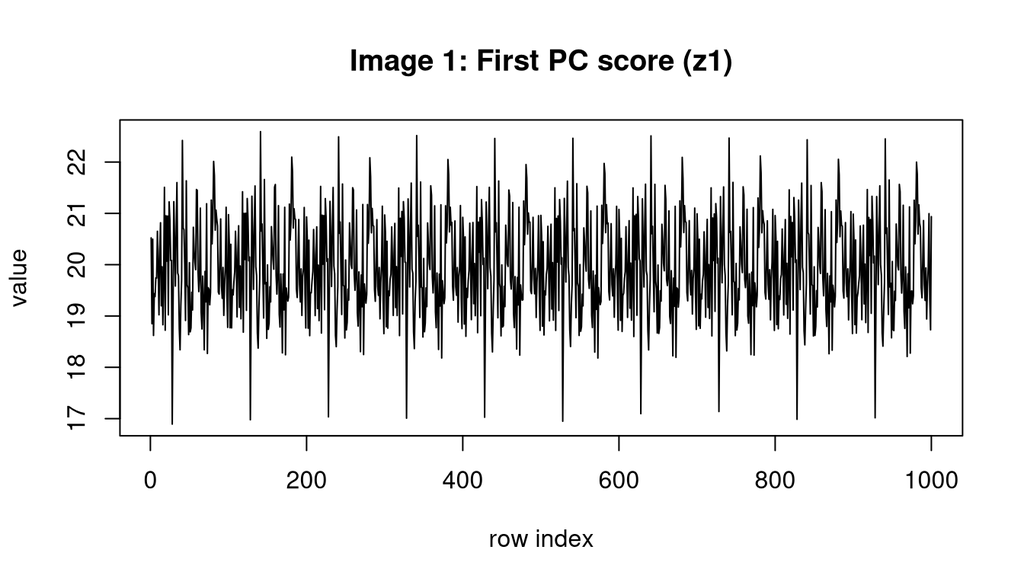

```r
plot(ec1$Z[, 1], type = "l", xlab = "row index", ylab = "value",
     main = "Image 1: First PC score (z1)")
```

## Image 2

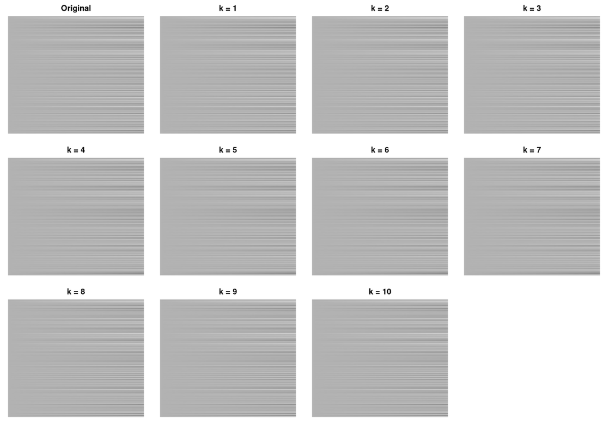

```r
img2 <- load_image("image2.csv")
par(mfrow = c(3, 4), mar = c(1,1,2,1))
show_image(img2, main = "Original")
for (k in 1:10) {
  res <- pca_compress(img2, k)
  show_image(res$approx, main = paste0("k = ", k))
}
```

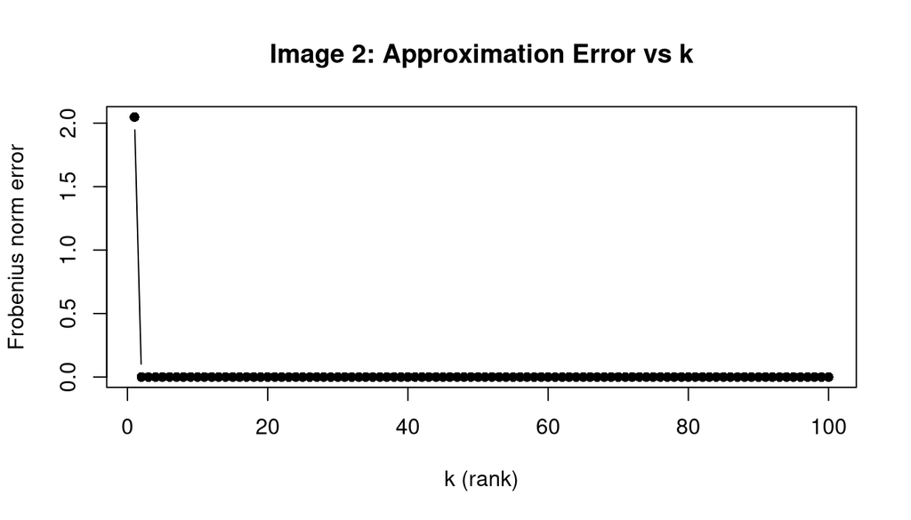

```r
par(mfrow = c(1, 1))
ec2 <- error_curve(img2)
plot(seq_along(ec2$errors), ec2$errors, type = "b", pch = 16,
     xlab = "k (rank)", ylab = "Frobenius norm error",
     main = "Image 2: Approximation Error vs k")
```

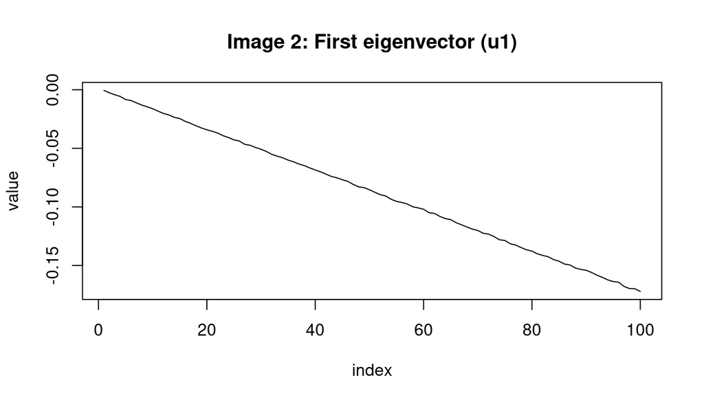

```r
plot(ec2$U[, 1], type = "l", xlab = "index", ylab = "value",
     main = "Image 2: First eigenvector (u1)")
```

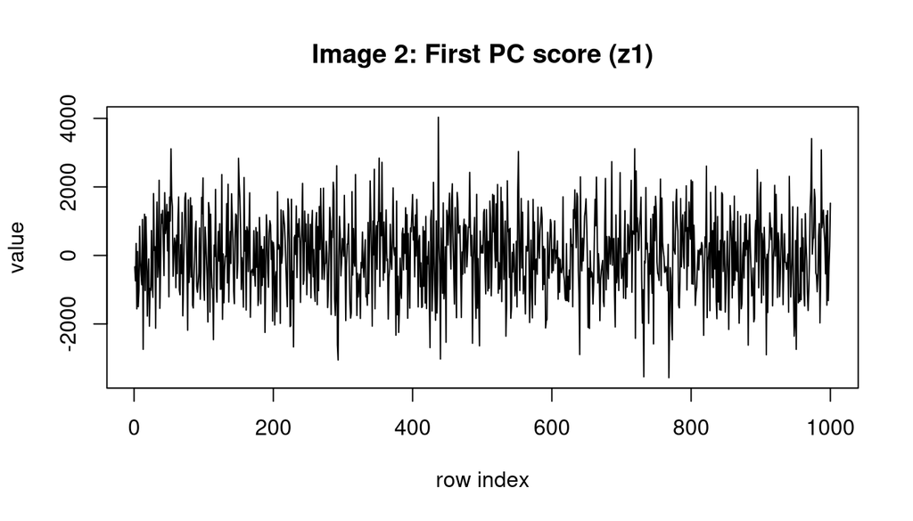

```r
plot(ec2$Z[, 1], type = "l", xlab = "row index", ylab = "value",
     main = "Image 2: First PC score (z1)")
```

The first eigenvector is a smooth, monotonically decreasing ramp across the columns, capturing the dominant large-scale gradient in the image. The first PC score varies irregularly from row to row, reflecting how strongly each row expresses that gradient pattern. Notably, the approximation error drops sharply after k = 1, indicating this image is nearly rank-1 — a single component is enough to reconstruct it almost perfectly.

**My opinion**: k = 1 or k = 2 is already sufficient — the approximation is visually indistinguishable from the original at these values.

## Image 3

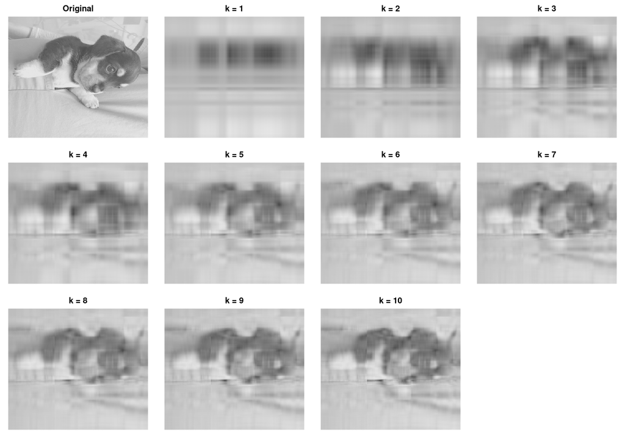

```r
img3 <- load_image("image3.csv")
par(mfrow = c(3, 4), mar = c(1,1,2,1))
show_image(img3, main = "Original")
for (k in 1:10) {
  res <- pca_compress(img3, k)
  show_image(res$approx, main = paste0("k = ", k))
}
```

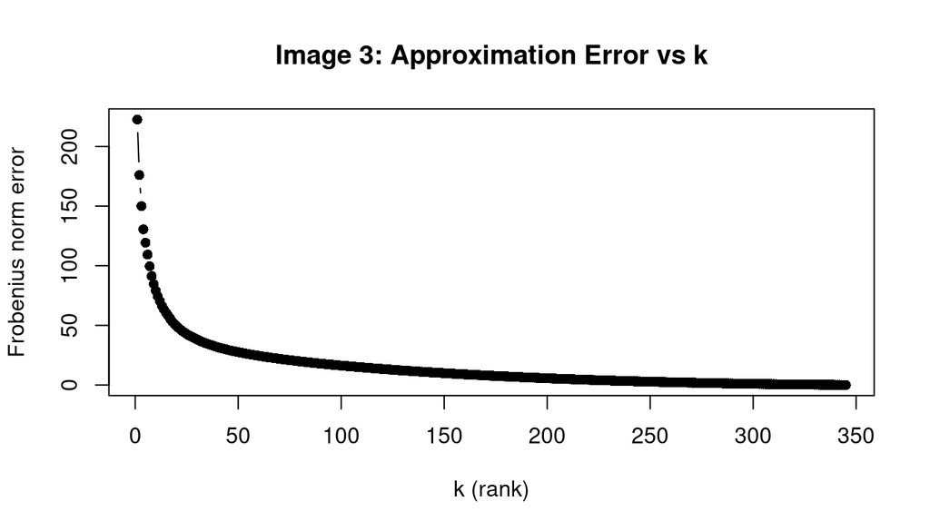

```r
par(mfrow = c(1, 1))
ec3 <- error_curve(img3)
plot(seq_along(ec3$errors), ec3$errors, type = "b", pch = 16,
     xlab = "k (rank)", ylab = "Frobenius norm error",
     main = "Image 3: Approximation Error vs k")
```

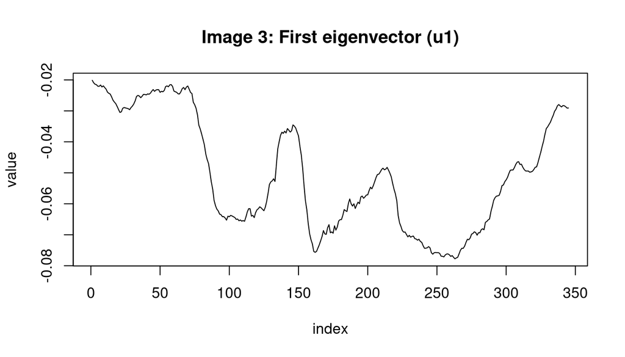

```r
plot(ec3$U[, 1], type = "l", xlab = "index", ylab = "value",
     main = "Image 3: First eigenvector (u1)")
```

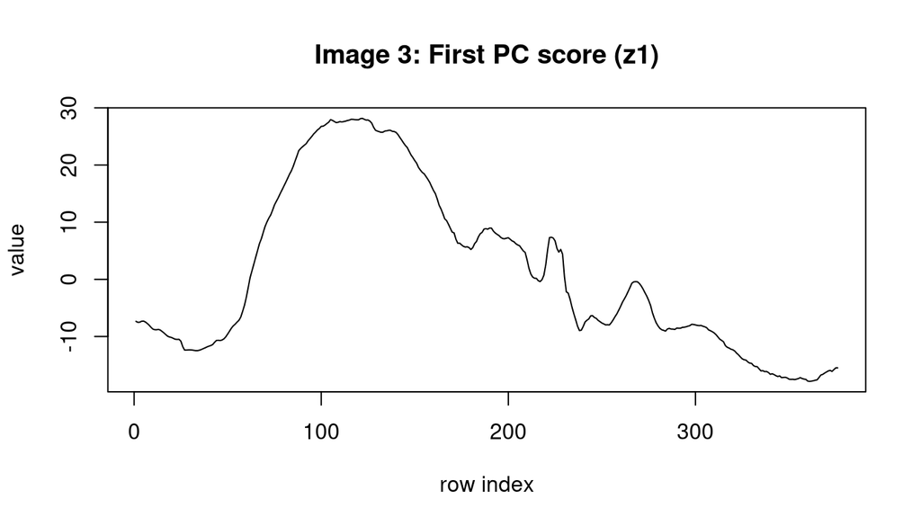

```r
plot(ec3$Z[, 1], type = "l", xlab = "row index", ylab = "value",
     main = "Image 3: First PC score (z1)")
```

The first eigenvector shows a smooth, wave-like pattern that mirrors the overall brightness structure of the image from top to bottom. The first PC score forms a bell-shaped curve, rising as the rows move from the bright bedding into the darker body of the puppy and back to lighter background. This reflects the image’s large-scale, spatially smooth intensity variation, which PCA can compress efficiently.

**My opinion**: k ≈ 8-10 gives a visually adequate approximation — the puppy’s shape, ear position, and shading become clearly recognizable by around k = 8, and results beyond that show diminishing returns.

## Image 4

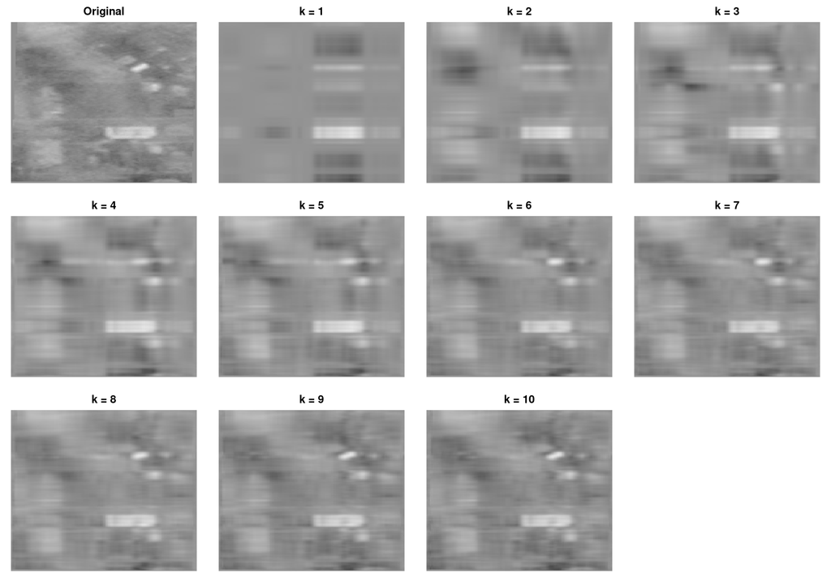

```r
img4 <- load_image("image4.csv")
par(mfrow = c(3, 4), mar = c(1,1,2,1))
show_image(img4, main = "Original")
for (k in 1:10) {
  res <- pca_compress(img4, k)
  show_image(res$approx, main = paste0("k = ", k))
}
```

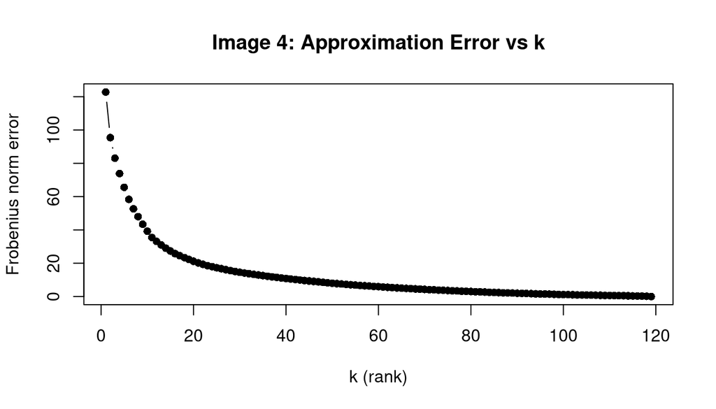

```r
par(mfrow = c(1, 1))
ec4 <- error_curve(img4)
plot(seq_along(ec4$errors), ec4$errors, type = "b", pch = 16,
     xlab = "k (rank)", ylab = "Frobenius norm error",
     main = "Image 4: Approximation Error vs k")
```

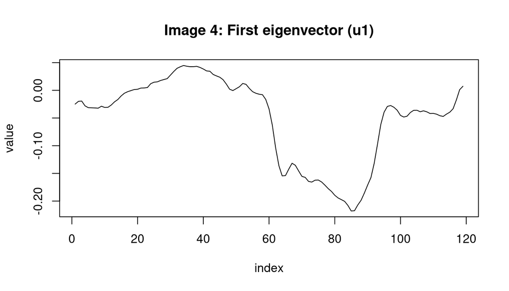

```r
plot(ec4$U[, 1], type = "l", xlab = "index", ylab = "value",
     main = "Image 4: First eigenvector (u1)")
```

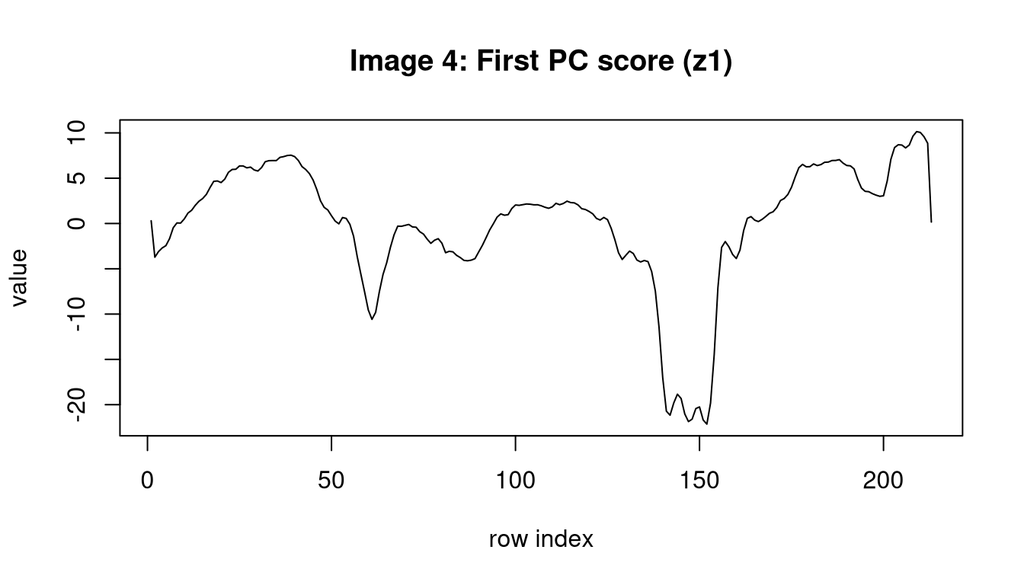

```r
plot(ec4$Z[, 1], type = "l", xlab = "row index", ylab = "value",
     main = "Image 4: First PC score (z1)")
```

The first eigenvector displays several smooth peaks and valleys corresponding to alternating light and dark regions (e.g., rooftops versus roads or shadows). The first PC score follows a similar pattern with a sharp dip in the middle, likely marking a distinct dark structure such as a shadow or building edge. The relatively smooth structure allows the image to be compressed effectively within a moderate number of components.

**My opinion**: k ≈ 6-7 is enough to make the main structures (buildings, roads, shadows) clearly identifiable, though a few fine details keep sharpening slightly up to k = 10.